```python
from IPython.display import HTML

HTML("""<script>
  function code_toggle() {
    if (code_shown){
      $('div.input').hide('500');
      $('#toggleButton').val('Show Code')
    } else {
      $('div.input').show('500');
      $('#toggleButton').val('Hide Code')
    }
    code_shown = !code_shown
  }

  $( document ).ready(function(){
    code_shown=false;
    $('div.input').hide()
  });
</script>
<form action="javascript:code_toggle()"><input type="submit" id="toggleButton" value="Show Code"></form>""")
```

# Finding persons of interest in the Enron scandal with Machine Learning

Enron Corporation is an energy company based in Houston Texas. In 2000, it was one of the largest companies in the United States. By 2002, it had collapsed into bankruptcy due to widespread corporate fraud. In the resulting Federal investigation, a significant amount of typically confidential information entered into the public record, including tens of thousands of emails and detailed financial data for top executives.

This project will attempt to identify the person of interest (POI) in the Enron scandal through a series of steps:

#### 1. Understanding the Dataset and Question

- Data Exploration
- Outlier Investigation

#### 2. Optimize Feature Selection/Engineering

- Create new features
- Intelligently select features

#### 3. Pick and Tune an Algorithm

- Examine Naive Bayes
- Examine Decision Tree
- Examine K Nearest Neighbors
- Examine and tune Support Vector Machine
- Examine Random Forest
- Pick an algorithm
- Tuning Decision Tree
- Tuning Linear SVM
- Tuning Random Forest
- Classifier Comparison Results

#### 4. Validate and Evaluate

- Final Decision Tree Results
- Viewing the tree
- Confusion matrix
- Classification report

[Learn more about the Enron scandal](https://en.wikipedia.org/wiki/Enron_scandal)

```python
#!/user/bin/python

# Preparing data and import setting
import sys
import os
import pickle
import matplotlib.pyplot as plt
import seaborn as sns
import numpy as np
import pandas as pd
import pprint as p

os.chdir("/home/ole/notebooks/p5/final_project/")
sys.path.append("/home/ole/notebooks/p5/tools/")

# set parameters for seaborn plots
sns.set(context='notebook',
        style='white',
        palette='Accent',
        font_scale=1.3)

# plotting display inside of notebook
%matplotlib inline

# # setting default figure size
plt.rcParams['figure.figsize'] = (14, 8)

from feature_format import featureFormat, targetFeatureSplit
from tester import dump_classifier_and_data, test_classifier
from tools import outlier_cleaner
```

```python
#### Load data dictionary from pickle file
with open("final_project_dataset.pkl", "r") as data_file:
    data_dict = pickle.load(data_file)
```

# Understanding the Dataset

## Data Exploration

### Taking a quick look at the first 5 observations

```python
import warnings
warnings.simplefilter(action = "ignore", category = FutureWarning)

# Turn data dictionary into pandas DataFrame object and transpose data orientation to display names per row using index
df = pd.DataFrame.from_dict(data_dict).T
df = df.convert_objects(convert_numeric=True)

# Reset index to zero and rename index column
df.reset_index(level=0, inplace=True)
df.rename(columns={'index':'name'}, inplace=True)
```

```python
df.head()
```

[output not shown]

```python
print "There are %d of observations (person) in this dataset, and %d features." %(len(df), len(df.columns))
```

```
There are 146 of observations (person) in this dataset, and 22 features.
```

### Data types

```python
df.info()
```

```
<class 'pandas.core.frame.DataFrame'>
RangeIndex: 146 entries, 0 to 145
Data columns (total 22 columns):
name                         146 non-null object
bonus                        82 non-null float64
deferral_payments            39 non-null float64
deferred_income              49 non-null float64
director_fees                17 non-null float64
email_address                146 non-null object
exercised_stock_options      102 non-null float64
expenses                     95 non-null float64
from_messages                86 non-null float64
from_poi_to_this_person      86 non-null float64
from_this_person_to_poi      86 non-null float64
loan_advances                4 non-null float64
long_term_incentive          66 non-null float64
other                        93 non-null float64
poi                          146 non-null bool
restricted_stock             110 non-null float64
restricted_stock_deferred    18 non-null float64
salary                       95 non-null float64
shared_receipt_with_poi      86 non-null float64
to_messages                  86 non-null float64
total_payments               125 non-null float64
total_stock_value            126 non-null float64
dtypes: bool(1), float64(19), object(2)
memory usage: 24.2+ KB
```

## Outlier Investigation

### Missing values

```python
df.isnull().sum()
```

```
name                           0
bonus                         64
deferral_payments            107
deferred_income               97
director_fees                129
email_address                  0
exercised_stock_options       44
expenses                      51
from_messages                 60
from_poi_to_this_person       60
from_this_person_to_poi       60
loan_advances                142
long_term_incentive           80
other                         53
poi                            0
restricted_stock              36
restricted_stock_deferred    128
salary                        51
shared_receipt_with_poi       60
to_messages                   60
total_payments                21
total_stock_value             20
dtype: int64
```

We can see from the sample above that there are quite a few missing values for each feature especially loan advances, director fees, restricted stock deferred, and deferal payments. I wonder if there are many missing values for each observation.

### Finding missing features

```python
# Missing values per person
row_null = df.isnull().sum(axis=1).idxmax()
df.loc[row_null]
```

```
name                         LOCKHART EUGENE E
bonus                                      NaN
deferral_payments                          NaN
deferred_income                            NaN
director_fees                              NaN
email_address                              NaN
exercised_stock_options                    NaN
expenses                                   NaN
from_messages                              NaN
from_poi_to_this_person                    NaN
from_this_person_to_poi                    NaN
loan_advances                              NaN
long_term_incentive                        NaN
other                                      NaN
poi                                      False
restricted_stock                           NaN
restricted_stock_deferred                  NaN
salary                                     NaN
shared_receipt_with_poi                    NaN
to_messages                                NaN
total_payments                             NaN
total_stock_value                          NaN
Name: 84, dtype: object
```

Suprisingly there is one person with no available data. This would skew the dataset even more! It might be best to remove this person from the dataset. We will deal with this in a later section.

### Top 15 persons with missing values

```python
# Missing values per person
copy = df
# Create column for nans and sum all null values
copy["nans"] = copy.isnull().sum(axis=1)
# show 10 largest person with nans
nan = copy[["name", "nans", "poi"]]
nan.nlargest(15, "nans")
```

|  | name | nans | poi |
| --- | --- | --- | --- |
| 84 | LOCKHART EUGENE E | 19 | False |
| 56 | GRAMM WENDY L | 17 | False |
| 115 | SCRIMSHAW MATTHEW | 17 | False |
| 127 | THE TRAVEL AGENCY IN THE PARK | 17 | False |
| 138 | WHALEY DAVID A | 17 | False |
| 142 | WODRASKA JOHN | 17 | False |
| 143 | WROBEL BRUCE | 17 | False |
| 24 | CHRISTODOULOU DIOMEDES | 16 | False |
| 25 | CLINE KENNETH W | 16 | False |
| 53 | GILLIS JOHN | 16 | False |
| 114 | SAVAGE FRANK | 16 | False |
| 133 | WAKEHAM JOHN | 16 | False |
| 14 | BLAKE JR. NORMAN P | 15 | False |
| 23 | CHAN RONNIE | 15 | False |
| 48 | FUGH JOHN L | 15 | False |

These top 15 people have 15 to 19 missing feature values, we will remove everyone who has more than 15 missing features.

### Viewing the distribution of some financial features

```
array([[<matplotlib.axes._subplots.AxesSubplot object at 0x7f0457494e90>,
        <matplotlib.axes._subplots.AxesSubplot object at 0x7f045734a410>]], dtype=object)
```

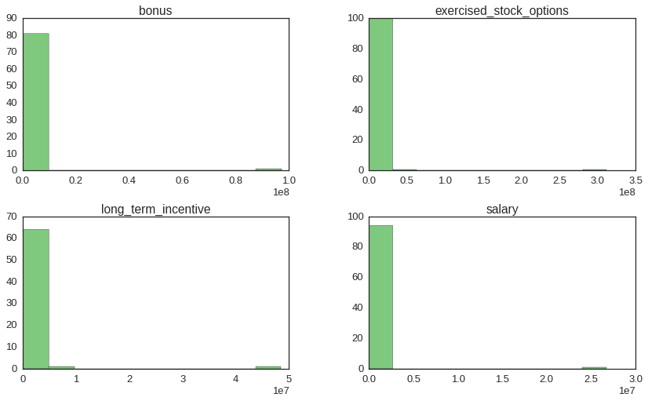

```python
# Let's take a look at the distribution of a few financial features
df.hist(column=["salary", "bonus", "exercised_stock_options", "long_term_incentive"], grid=False)
```

It is really hard to see what's going on with the above histograms. We can only see two extremes.

### Using a scatter plot to get a better look at the features above

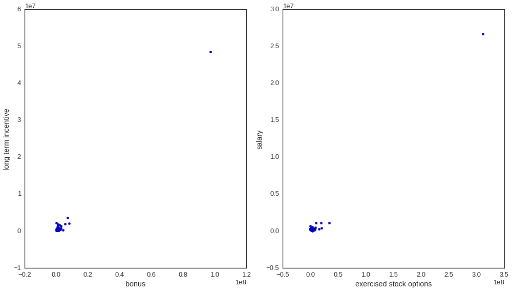

```python
# Plot some financial features
f, (ax1, ax2) = plt.subplots(1, 2)
ax1.scatter(df["bonus"], df["long_term_incentive"])
ax1.set_xlabel("bonus")
ax1.set_ylabel("long term incentive")
ax2.scatter(df["exercised_stock_options"], df["salary"])
ax2.set_xlabel("exercised stock options")
ax2.set_ylabel("salary")
plt.tight_layout()
plt.show()
```

Here, the scatterplot give us a better visual of the data. There is an outlier at the top right corner. This is consistent with what we observed from then Enron PDF file.

### What about boxplots?

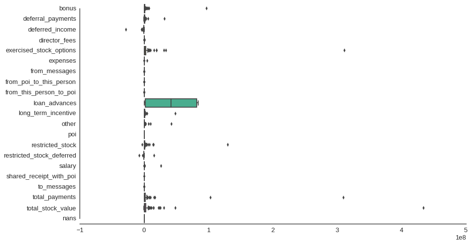

```python
ax = sns.boxplot(data=df, orient="h")
sns.despine(trim=True)
```

It's a little difficult to see the boxplots next to each other but `loan_advances` definately stand out. Another trend that we see here is the number of outliers. `Exercised_stock_options` have an extreme high outlier value follow by `restricted_stock` and `bonus`. Here the `total_stock_values` and `total_payments` are the sum of the financial and stock features as shown in the PDF file.

### Confirming the outlier with the top 20 earners

```python
# Result show a TOTAL which is something we do not want to include in our data because it is not a person's record
bonus = df[["name", "poi", "bonus", "restricted_stock", "exercised_stock_options", "long_term_incentive", "other", "loan_advances"]]
bonus.nlargest(20, "bonus")
```

|  | name | poi | bonus | restricted_stock | exercised_stock_options | long_term_incentive | other | loan_advances |
| --- | --- | --- | --- | --- | --- | --- | --- | --- |
| 130 | TOTAL | False | 97343619.0 | 130322299.0 | 311764000.0 | 48521928.0 | 42667589.0 | 83925000.0 |
| 78 | LAVORATO JOHN J | False | 8000000.0 | 1008149.0 | 4158995.0 | 2035380.0 | 1552.0 | NaN |
| 79 | LAY KENNETH L | True | 7000000.0 | 14761694.0 | 34348384.0 | 3600000.0 | 10359729.0 | 81525000.0 |
| 122 | SKILLING JEFFREY K | True | 5600000.0 | 6843672.0 | 19250000.0 | 1920000.0 | 22122.0 | NaN |
| 7 | BELDEN TIMOTHY N | True | 5249999.0 | 157569.0 | 953136.0 | NaN | 210698.0 | NaN |
| 0 | ALLEN PHILLIP K | False | 4175000.0 | 126027.0 | 1729541.0 | 304805.0 | 152.0 | NaN |
| 75 | KITCHEN LOUISE | False | 3100000.0 | 466101.0 | 81042.0 | NaN | 93925.0 | NaN |
| 31 | DELAINEY DAVID W | True | 3000000.0 | 1323148.0 | 2291113.0 | 1294981.0 | 1661.0 | NaN |
| 139 | WHALLEY LAWRENCE G | False | 3000000.0 | 2796177.0 | 3282960.0 | 808346.0 | 301026.0 | NaN |
| 91 | MCMAHON JEFFREY | False | 2600000.0 | 558801.0 | 1104054.0 | 694862.0 | 297353.0 | NaN |
| 42 | FALLON JAMES B | False | 2500000.0 | 1392142.0 | 940257.0 | 374347.0 | 401481.0 | NaN |
| 47 | FREVERT MARK A | False | 2000000.0 | 4188667.0 | 10433518.0 | 1617011.0 | 7427621.0 | 2000000.0 |
| 116 | SHANKMAN JEFFREY A | False | 2000000.0 | 630137.0 | 1441898.0 | 554422.0 | 1191.0 | NaN |
| 112 | RICE KENNETH D | True | 1750000.0 | 2748364.0 | 19794175.0 | 1617011.0 | 174839.0 | NaN |
| 64 | HICKERSON GARY J | False | 1700000.0 | 441096.0 | NaN | 69223.0 | 1936.0 | NaN |
| 59 | HANNON KEVIN P | True | 1500000.0 | 853064.0 | 5538001.0 | 1617011.0 | 11350.0 | NaN |
| 121 | SHERRIFF JOHN R | False | 1500000.0 | 1293424.0 | 1835558.0 | 554422.0 | 1852186.0 | NaN |
| 15 | BOWEN JR RAYMOND M | True | 1350000.0 | 252055.0 | NaN | 974293.0 | 1621.0 | NaN |
| 43 | FASTOW ANDREW S | True | 1300000.0 | 1794412.0 | NaN | 1736055.0 | 277464.0 | NaN |
| 20 | CALGER CHRISTOPHER F | True | 1250000.0 | 126027.0 | NaN | 375304.0 | 486.0 | NaN |

The top values belong to TOTAL. From data PDF file, TOTAL is the sum of all persons per feature. There is another record unrealated to any person, THE TRAVEL AGENCY IN THE PARK. Inaddition, the columns total_payments and total_stock_value seem to be an aggregate of the financial features.

Note: Although John Lavorato, Allen Phillip and Kitchen Louise are the few among the top earners, they are not pois. Removing them from the dataset will help our classifier learn better.

## Outliers to remove

- TOTAL
- THE TRAVEL AGENCY IN THE PARK
- LOCKHART EUGENE E
- GRAMM WENDY L
- SCRIMSHAW MATTHEW
- WHALEY DAVID A
- WODRASKA JOHN
- WROBEL BRUCE
- CHRISTODOULOU DIOMEDES
- CLINE KENNETH W
- GILLIS JOHN
- SAVAGE FRANK
- WAKEHAM JOHN
- LAVORATO JOHN J
- ALLEN PHILLIP K
- KITCHEN LOUISE
- WHALLEY LAWRENCE G
- MCMAHON JEFFREY
- FALLON JAMES B
- SHANKMAN JEFFREY A
- HICKERSON GARY J
- SHERRIFF JOHN R

As for total_payments, total_stock_value, and extreme outlier values we will revisit them when dealing with feature selection.

```python
# Remove outliers
outliers = {
    "TOTAL",
    "THE TRAVEL AGENCY IN THE PARK",
    "LOCKHART EUGENE E",
    "GRAMM WENDY L,"
    "SCRIMSHAW MATTHEW",
    "WHALEY DAVID A",
    "WODRASKA JOHN",
    "WROBEL BRUCE",
    "CHRISTODOULOU DIOMEDES",
    "CLINE KENNETH W",
    "GILLIS JOHN",
    "SAVAGE FRANK",
    "WAKEHAM JOHN",
    "LAVORATO JOHN J",
    "ALLEN PHILLIP K",
    "KITCHEN LOUISE",
    "WHALLEY LAWRENCE G",
    "MCMAHON JEFFREY",
    "FALLON JAMES B",
    "SHANKMAN JEFFREY A",
    "HICKERSON GARY J",
    "SHERRIFF JOHN R"
}
clean_data = outlier_cleaner(data_dict, outliers)
```

```python
clean_df = pd.DataFrame.from_dict(data_dict).T
clean_df = clean_df.convert_objects(convert_numeric=True)

# Reset index to zero and rename index column
clean_df.reset_index(level=0, inplace=True)
clean_df.rename(columns={'index':'name'}, inplace=True)
```

### Checking the distributions of data features

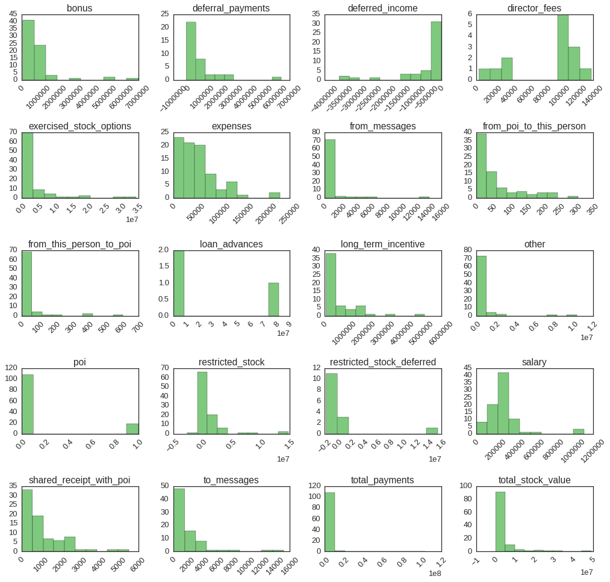

```python
# Checking for data distribution using histogram
clean_df.hist(xrot=45, figsize=(17, 16), grid="off")
plt.subplots_adjust(hspace=.8)
# plt.tight_layout()
plt.show()
```

All the features look much better now. We can observe more details in each of the distribution and get a general idea of the shape.

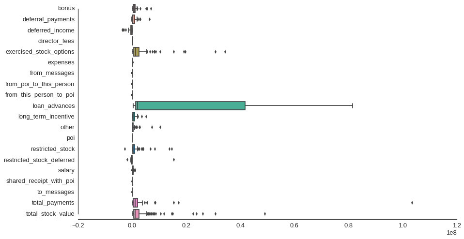

```python
ax = sns.boxplot(data=clean_df, orient="h")
sns.despine(trim=True)
```

### Checking the top 10 earners from the clean dataset

```python
top_earners = clean_df[["name", "poi", "bonus", "exercised_stock_options", "total_payments", "total_stock_value"]]
top_earners["total_earned"] = top_earners["total_payments"] + top_earners["total_stock_value"]
top_earners.nlargest(10, "total_earned")
```

|  | name | poi | bonus | exercised_stock_options | total_payments | total_stock_value | total_earned |
| --- | --- | --- | --- | --- | --- | --- | --- |
| 71 | LAY KENNETH L | True | 7000000.0 | 34348384.0 | 103559793.0 | 49110078.0 | 152669871.0 |
| 109 | SKILLING JEFFREY K | True | 5600000.0 | 19250000.0 | 8682716.0 | 26093672.0 | 34776388.0 |
| 43 | FREVERT MARK A | False | 2000000.0 | 10433518.0 | 17252530.0 | 14622185.0 | 31874715.0 |
| 59 | HIRKO JOSEPH | True | NaN | 30766064.0 | 91093.0 | 30766064.0 | 30857157.0 |
| 93 | PAI LOU L | False | 1000000.0 | 15364167.0 | 3123383.0 | 23817930.0 | 26941313.0 |
| 102 | RICE KENNETH D | True | 1750000.0 | 19794175.0 | 505050.0 | 22542539.0 | 23047589.0 |
| 122 | WHITE JR THOMAS E | False | 450000.0 | 1297049.0 | 1934359.0 | 15144123.0 | 17078482.0 |
| 2 | BAXTER JOHN C | False | 1200000.0 | 6680544.0 | 5634343.0 | 10623258.0 | 16257601.0 |
| 124 | YEAGER F SCOTT | True | NaN | 8308552.0 | 360300.0 | 11884758.0 | 12245058.0 |
| 32 | DIMICHELE RICHARD G | False | 1000000.0 | 8191755.0 | 2368151.0 | 8317782.0 | 10685933.0 |

Although there are still a couple of extreme values in the dataset, we want our classifier to learn and be able to identify non-pois that earned large sums.

### How many person of interest or poi are there?

```python
poi = clean_df["poi"].value_counts()
poi_ptc = (poi/poi.sum())*100
poi_ratio = poi[[0]].div(poi[1])
```

```python
poi
```

```
False    108
True      18
Name: poi, dtype: int64
```

```python
poi_ptc
```

```
False    85.714286
True     14.285714
Name: poi, dtype: float64
```

### Poi Ratio

```python
poi_ratio
```

```
False    6.0
Name: poi, dtype: float64
```

### Poi stats

```python
poi = clean_df.groupby("poi").median().T
poi
```

| poi | False | True |
| --- | --- | --- |
| bonus | 600000.0 | 1275000.0 |
| deferral_payments | 243952.0 | 202911.0 |
| deferred_income | -113784.0 | -262500.0 |
| director_fees | 103121.0 | NaN |
| exercised_stock_options | 886231.0 | 3914557.0 |
| expenses | 41626.0 | 50448.5 |
| from_messages | 36.0 | 44.5 |
| from_poi_to_this_person | 23.0 | 62.0 |
| from_this_person_to_poi | 4.0 | 15.5 |
| loan_advances | 1200000.0 | 81525000.0 |
| long_term_incentive | 369721.0 | 1134637.0 |
| other | 7482.0 | 149204.0 |
| restricted_stock | 387251.0 | 985032.0 |
| restricted_stock_deferred | -140264.0 | NaN |
| salary | 248346.0 | 278601.0 |
| shared_receipt_with_poi | 552.0 | 1589.0 |
| to_messages | 865.0 | 1875.0 |
| total_payments | 999356.0 | 1754027.5 |
| total_stock_value | 1014505.0 | 2206835.5 |

# Optimize Feature Selection / Engineering

The observed Enron dataset has a total of 22 features. These are a combination of financial and email attributes and `poi`. Investigating these features will help us understand which features are highly correlated or irrelevant to build a more effective algorithm.

> ["Good feature subsets contain features highly correlated with the classification, yet uncorrelated to each other"](https://en.wikipedia.org/wiki/Feature_selection)

### Original features list

features_list = [ 'poi', 'salary', 'deferral_payments', 'loan_advances', 'bonus', 'restricted_stock_deferred', 'deferred_income', 'expenses', 'exercised_stock_options', 'other', 'long_term_incentive', 'restricted_stock', 'director_fees', 'to_messages', 'from_poi_to_this_person', 'from_messages', 'from_this_person_to_poi', 'shared_receipt_with_poi' ]

```python
features_list = [
    'poi',
    'salary',
    'deferral_payments',
    'loan_advances',
    'bonus',
    'restricted_stock_deferred',
    'deferred_income',
    'expenses',
    'exercised_stock_options',
    'other',
    'long_term_incentive',
    'restricted_stock',
    'director_fees',
    'to_messages',
    'from_poi_to_this_person',
    'from_messages',
    'from_this_person_to_poi',
    'shared_receipt_with_poi'
]
```

### Which features are correlated?

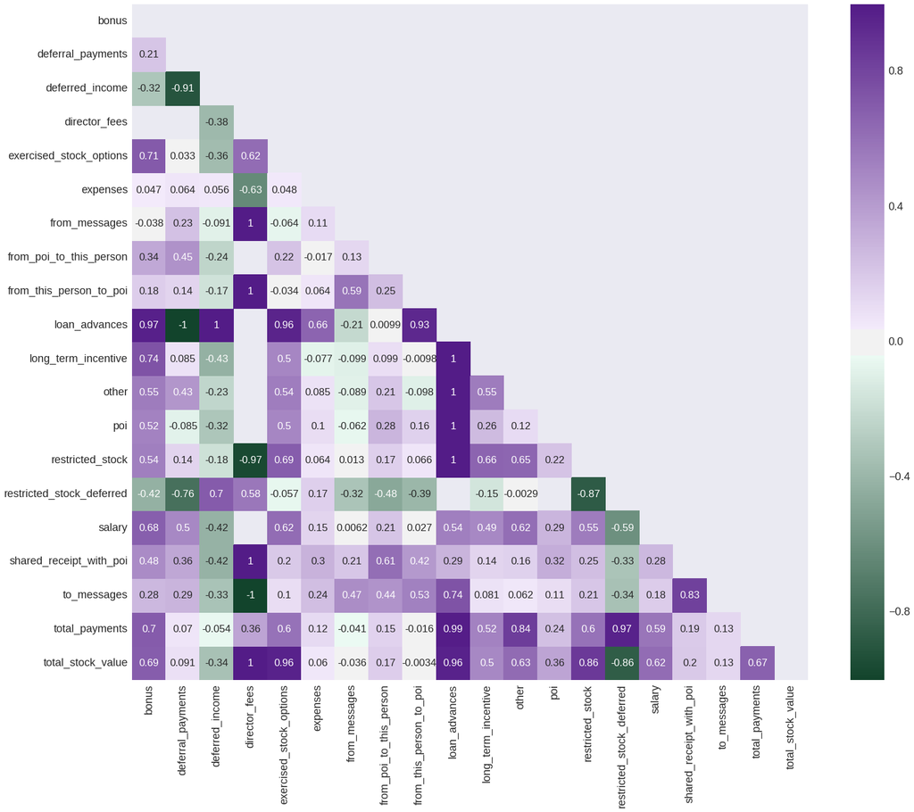

```python
# Correlation matrix
sns.set(font_scale=1.8)
fig, ax = plt.subplots(figsize=(25, 20))
corr = clean_df.corr()
# Generate a mask for the upper triangle
mask = np.zeros_like(corr, dtype=np.bool)
mask[np.triu_indices_from(mask)] = True
cmap=sns.diverging_palette(145, 280, s=85, l=25, n=7, as_cmap=True)
sns.heatmap(corr, mask=mask, annot=True, vmax=.3, cmap=cmap, annot_kws={"size": 17})
```

The correlation matrix show a couple of features that are highly correlated to poi. Features like loan advances and director fees have both positive and negative relationships with other features like bonus, deferred payments, deferred income, excercised stock option and from poi to this person have coefficients above 0.9. In general, financial features are more dominant then the email features in this dataset.

## Feature Engineering

The correlation matrix above showed some email features that have a low correlation. Let's look at from_poi_to_this_person' and from_this_person_to_poi on a scatter plot.

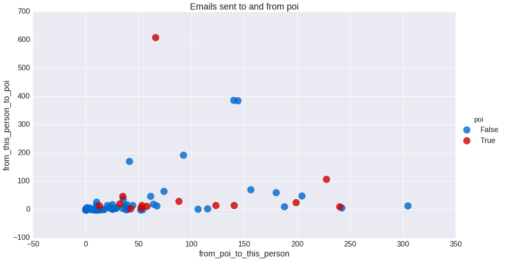

```python
# Emails sent to and from poi scatter plot
colors = ["#0067cd", "#cd0000"]
sns.set_palette(colors)
sns.lmplot(x = "from_poi_to_this_person",
           y = "from_this_person_to_poi",
           data = clean_df,
           fit_reg = False,
           hue = "poi",
           x_jitter = .3,
           y_jitter = .3,
           aspect = 1.75,
           size = 9,
           scatter_kws = {"marker": "D", "s": 300})

plt.title("Emails sent to and from poi")
plt.xlabel('from_poi_to_this_person')
plt.ylabel('from_this_person_to_poi')
```

Using red to mark the Enron employees who are poi makes it easier for us to observe. In this case, we could still see some outliers but there is no clear pattern that we can spot.

### Create new features:

"fraction_from_poi" : the proportion of sent messages from poi to a person  
"fraction_to_poi" : the proportion of sent messages from a person to poi

Here we take the proportion of the from and to poi from the total emails to measure the relatonship. We will assume that if there is no emails to or from poi then NaN values will be replaced with 0.

```python
# Take the ratio from total messages
clean_df["fraction_to_poi"] = clean_df["from_poi_to_this_person"]/clean_df["to_messages"]
clean_df["fraction_from_poi"] = clean_df["from_this_person_to_poi"]/clean_df["from_messages"]
# clean_df.head().T
# Fill in NaNs
clean_df = clean_df.fillna(0)
my_dict = clean_df.set_index("name").T
my_dict_e = clean_df.set_index("name").T
```

### Viewing new features

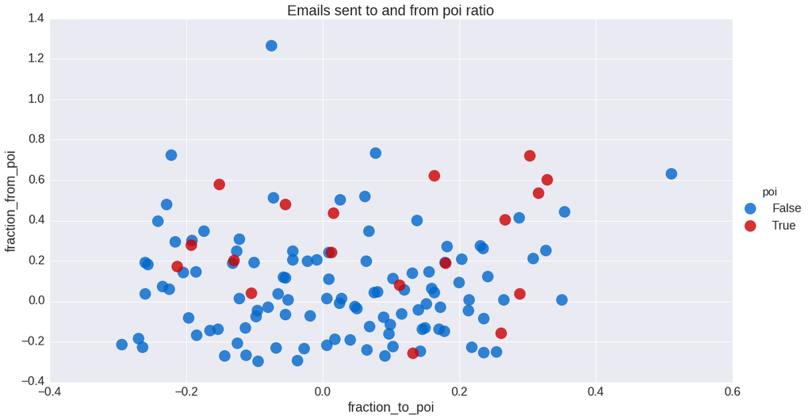

```python
# Emails sent to and from poi ratio scatter plot
colors = ["#0067cd", "#cd0000"]
sns.set_palette(colors)
sns.lmplot(x = "fraction_to_poi",
           y = "fraction_from_poi",
           data = clean_df,
           fit_reg = False,
           hue = "poi",
           x_jitter = .3,
           y_jitter = .3,
           aspect = 1.75,
           size = 9,
           scatter_kws = {"marker": "D", "s": 300})

plt.title("Emails sent to and from poi ratio")
plt.xlabel('fraction_to_poi')
plt.ylabel('fraction_from_poi')
```

With the ratios in place, we can visually see all the data points on the scale. This feature could be useful with principle component analysis.

### Engineered features list

features_list_e = [ 'poi', 'salary', 'deferral_payments', 'loan_advances', 'bonus', 'restricted_stock_deferred', 'deferred_income', 'expenses', 'exercised_stock_options', 'other', 'long_term_incentive', 'restricted_stock', 'director_fees', 'to_messages', 'from_poi_to_this_person', 'from_messages', 'from_this_person_to_poi', 'shared_receipt_with_poi', 'fraction_from_poi', 'fraction_to_poi' ]

```python
# Adding new features to feature list
features_list_e = [
    'poi',
    'salary',
    'deferral_payments',
    'loan_advances',
    'bonus',
    'restricted_stock_deferred',
    'deferred_income',
    'expenses',
    'exercised_stock_options',
    'other',
    'long_term_incentive',
    'restricted_stock',
    'director_fees',
    'to_messages',
    'from_poi_to_this_person',
    'from_messages',
    'from_this_person_to_poi',
    'shared_receipt_with_poi',
    'fraction_from_poi',
    'fraction_to_poi'
]
```

```python
### ORIGINAL DATASET
### Store to my_dataset for easy export below.
my_dataset = my_dict.to_dict()

### Extract features and labels from dataset for local testing
data = featureFormat(my_dataset, features_list, sort_keys = True)
labels, features = targetFeatureSplit(data)
```

```python
### ENGINEERED DATASET
### Store to my_dataset for easy export below.
my_dataset_e = my_dict_e.to_dict()

### Extract features and labels from dataset for local testing
data_e = featureFormat(my_dataset_e, features_list_e, sort_keys = True)
labels_e, features_e = targetFeatureSplit(data_e)
```

## Intelligently select features

Now that we created a few new features, lets compare the engineered features list to the original features list. There are three methods in which we can explore. First, we will try a filter method where we will use Sci-kit learn SelectKbest to understand the importance of each feature. SelectKbest is a univariate feature selection method that applies a statistical measure to evaluate each feature on their own and rank them accordingly. For this case, we will look at the preset ANOVA f_statistics.

### Feature ranking with Kbest using original features

```python
from sklearn.feature_selection import SelectKBest
kb = SelectKBest().fit(features, labels)
importances_kb = kb.scores_  # Extract feature importances
indices_kb = np.argsort(importances_kb)[::-1]
print "Feature indices:"
print indices_kb
# Print the feature ranking
print('\nFeature Ranking:')
for f in range(17):
    # [1:] is important since the first item is "poi"!
    print("%d. %s (%0.2f)" % (f + 1, features_list[1:][indices_kb[f]], importances_kb[indices_kb[f]]))
```

```
Feature indices:
[ 3  7  0 16  5 13  9 10  6  2  8 15 12 11  1 14  4]

Feature Ranking:
1. bonus (49.84)
2. exercised_stock_options (21.47)
3. salary (18.03)
4. shared_receipt_with_poi (13.18)
5. deferred_income (12.55)
6. from_poi_to_this_person (10.71)
7. long_term_incentive (9.46)
8. restricted_stock (7.95)
9. expenses (7.48)
10. loan_advances (6.19)
11. other (3.60)
12. from_this_person_to_poi (3.48)
13. to_messages (2.60)
14. director_fees (2.09)
15. deferral_payments (0.27)
16. from_messages (0.10)
17. restricted_stock_deferred (0.08)
```

### Feature ranking with Kbest using engineered features

```python
from sklearn.feature_selection import SelectKBest
kb_e = SelectKBest().fit(features_e, labels_e)
importances_kb_e = kb_e.scores_  # Extract feature importances
indices_kb_e = np.argsort(importances_kb_e)[::-1]
print "Engineered feature indices:"
print indices_kb_e
# Print the feature ranking
print('\nFeature Ranking:')
for f in range(19):
    # [1:] is important since the first item is "poi"!
    print("%d. %s (%0.2f)" % (f + 1, features_list_e[1:][indices_kb_e[f]], importances_kb_e[indices_kb_e[f]]))
```

```
Engineered feature indices:
[ 3  7  0 17 16  5 13  9 10  6  2  8 15 12 18 11  1 14  4]

Feature Ranking:
1. bonus (49.84)
2. exercised_stock_options (21.47)
3. salary (18.03)
4. fraction_from_poi (16.19)
5. shared_receipt_with_poi (13.18)
6. deferred_income (12.55)
7. from_poi_to_this_person (10.71)
8. long_term_incentive (9.46)
9. restricted_stock (7.95)
10. expenses (7.48)
11. loan_advances (6.19)
12. other (3.60)
13. from_this_person_to_poi (3.48)
14. to_messages (2.60)
15. fraction_to_poi (2.53)
16. director_fees (2.09)
17. deferral_payments (0.27)
18. from_messages (0.10)
19. restricted_stock_deferred (0.08)
```

Kbest's scores for each feature are the same for both lists. It also confirmed that the financial features are among the top 3 scores. Although most features retained their score, it is interesting to see that one of the engineered feature made it to the top 5! This means that the new added features have an impact so we will include the added features for future testing.

# 3 Pick and Tune an Algorithm

Before testing any algorithm, using a dummy classifier will provide an sanity check for future testing. The dummy classifier uses simple rules to implement strategies:

- `stratified` generates random predictions by respecting the training set class distribution.
- `most_frequent` always predicts the most frequent label in the training set.
- `prior` always predicts the class that maximizes the class prior.
- `uniform` generates predictions uniformly at random.
- `constant` always predicts a constant label that is provided by the user.

[more info](http://scikit-learn.org/stable/modules/model_evaluation.html#dummy-estimators)

## ZeroR | Dummy classifier

```python
# Using a dummy classifier to gage future performance
from sklearn.dummy import DummyClassifier

clf = DummyClassifier(random_state=42)

print "\nThis is the result for the simple classifier test on the engineered features:"
test_classifier(clf, my_dataset_e, features_list_e)
```

```
This is the result for the simple classifier test on the engineered features:
DummyClassifier(constant=None, random_state=42, strategy='stratified')
	Accuracy: 0.69231	Precision: 0.16667	Recall: 0.25000	F1: 0.20000	F2: 0.22727
	Total predictions: 13000	True positives:  500	False positives: 2500	False negatives: 1500	True negatives: 8500
```

The simple classifier score a 0.6923, a pretty good accuracy score. However, the precision, recall and f1 are around 0.16 and 0.25. This means that it's unable to identify pois and non-pois that well. Now we have an idea of the scores, we can start spot checking some classifiers before choosing an algorithm and tuning it.

### Splitting the dataset

One methodological mistake is performing learning parameters and predicting function on the same dataset.Therefore it is important that we split our data into training and testing sets. Overfitting happens when we use the same dataset to train and predict because the algorithm is accustom to previously seen data. Splitting the data will all some variance in which the algorithm is expose to new information. Gaging the model performance this way is similar to a real life situation. Here we will reserve 30% for testing and 70% for training. This will also help speed up our testing time.

```python
# Split test data to for training and testing for dataset with feature engineering
from sklearn.model_selection import train_test_split
features_train_e, features_test_e, labels_train_e, labels_test_e = train_test_split(
    data_e, labels_e, test_size = 0.3, random_state=42)
```

## Get a baseline from different classifiers

We will be evaluating our classifiers mainly through two metrics. These are precision and recall.

> **Metric definition**

> **Precision: True Positive / (True Positive + False Positive)**  
> Out of all the items labeled as positive, how many truly belong to the positive class.

> **Recall: True Positive / (True Positive + False Negative)**  
> Out of all the items that are truly positive, how many were correctly classified as positive. Or simply, how many positive items were 'recalled' from the dataset.

When we examine the classifiers, we will use a simple pipeline. The combination consist of a data standardizing, feature selection method and an algorithm below.

**Standardization:**

- Minmax scaler
- Standard scaler
- Robust scaler

**Feature selection:**

- K best
- PCA

## 3.1 Examine Naive Bayes

```python
### Import Sklearn modules
from sklearn.metrics import make_scorer, precision_score, recall_score
from tools import custom_score
from tester import test_classifier
from sklearn.decomposition import PCA
from sklearn.feature_selection import SelectKBest
from sklearn.pipeline import Pipeline, FeatureUnion
from sklearn.preprocessing import StandardScaler, MinMaxScaler, RobustScaler
from sklearn.model_selection import StratifiedShuffleSplit, GridSearchCV, RandomizedSearchCV
from sklearn.tree import DecisionTreeClassifier
from sklearn.naive_bayes import GaussianNB
from sklearn.neighbors import KNeighborsClassifier
from sklearn.svm import SVC
from sklearn.linear_model import LogisticRegression
from sklearn.ensemble import RandomForestClassifier
```

```python
### Define scalers
standard = StandardScaler()
scaler = MinMaxScaler()
robust = RobustScaler()

### Feature Selection
kbest = SelectKBest()
pca = PCA()  # Reduce dimension
```

```python
# Combine features
combined_features = FeatureUnion([
#     ("SCALER", scaler),
    ("KBEST", kbest)
])

# Instantiate the model
gnb = GaussianNB()

# Create pipeline
pipe_gnb = Pipeline([
    ("FEATURES", combined_features),
    ("CLF", gnb)
])

pipe_gnb.fit(features_train_e, labels_train_e)  # Fit model
print "Naive Bayes test results:\n"
%time test_classifier(pipe_gnb, my_dataset_e, features_list_e)
```

```
Naive Bayes test results:
```

```
Pipeline(steps=[('FEATURES', FeatureUnion(n_jobs=1,
       transformer_list=[('KBEST', SelectKBest(k=10, score_func=<function f_classif at 0x7f0457ee2758>))],
       transformer_weights=None)), ('CLF', GaussianNB(priors=None))])
	Accuracy: 0.84808	Precision: 0.50816	Recall: 0.38900	F1: 0.44067	F2: 0.40814
	Total predictions: 13000	True positives:  778	False positives:  753	False negatives: 1222	True negatives: 10247

CPU times: user 3.68 s, sys: 0 ns, total: 3.68 s
Wall time: 3.71 s
```

**Note:** with Naive Bayes, the scores stayed the same with or without the scaler in the pipeline.

## 3.2 Examine Decision Tree

```python
combined_features = FeatureUnion([
    ("SCALER", scaler),
    ("KBEST", kbest)
#     ("PCA", pca)
])  # Combine features

dt = DecisionTreeClassifier()  # Instantiate the model

# Create pipeline
pipe_dt = Pipeline([
    ("FEATURES", combined_features),
    ("CLF", dt)
])

pipe_dt = pipe_dt.fit(features_train_e, labels_train_e)  # Fit model
print "Decision Tree test results:\n"
%time test_classifier(pipe_dt, my_dataset_e, features_list_e)
```

```
Decision Tree test results:

Pipeline(steps=[('FEATURES', FeatureUnion(n_jobs=1,
       transformer_list=[('SCALER', MinMaxScaler(copy=True, feature_range=(0, 1))), ('KBEST', SelectKBest(k=10, score_func=<function f_classif at 0x7f0457ee2758>))],
       transformer_weights=None)), ('CLF', DecisionTreeClassifier(class_weight=None, criter...it=2, min_weight_fraction_leaf=0.0,
            presort=False, random_state=None, splitter='best'))])
	Accuracy: 0.84523	Precision: 0.49677	Recall: 0.46100	F1: 0.47822	F2: 0.46774
	Total predictions: 13000	True positives:  922	False positives:  934	False negatives: 1078	True negatives: 10066

CPU times: user 5.69 s, sys: 0 ns, total: 5.69 s
Wall time: 5.72 s
```

Running the same pipeline for the decision tree classifier, we still get 0.84523 for accuracy score and an improved F1 score of 0.47822. Both precision and recall are above 0.4.

**Note:** this pipeline recall score and precision score is slightly higher with a MinMax scaler than the Standard scaler.

## 3.3 Examine K Nearest Neighbors

```python
combined_features = FeatureUnion([
    ("SCALER", scaler),
    ("KBEST", kbest)
])  # Combine features

knn = KNeighborsClassifier()  # Instantiate the model

# Create pipeline
pipe_knn = Pipeline([
    ("FEATURES", combined_features),
    ("CLF", knn)
])

pipe_knn.fit(features_train_e, labels_train_e)  # Fit model
print "K Nearest Neigbors test results:\n"
%time test_classifier(pipe_knn, my_dataset_e, features_list_e)
```

```
K Nearest Neigbors test results:

Pipeline(steps=[('FEATURES', FeatureUnion(n_jobs=1,
       transformer_list=[('SCALER', MinMaxScaler(copy=True, feature_range=(0, 1))), ('KBEST', SelectKBest(k=10, score_func=<function f_classif at 0x7f0457ee2758>))],
       transformer_weights=None)), ('CLF', KNeighborsClassifier(algorithm='auto', leaf_size=30, metric='minkowski',
           metric_params=None, n_jobs=1, n_neighbors=5, p=2,
           weights='uniform'))])
	Accuracy: 0.86000	Precision: 0.66667	Recall: 0.18000	F1: 0.28346	F2: 0.21077
	Total predictions: 13000	True positives:  360	False positives:  180	False negatives: 1640	True negatives: 10820

CPU times: user 5.83 s, sys: 0 ns, total: 5.83 s
Wall time: 5.84 s
```

So far, this classifier was able to get the highest precision score of 0.66667 but the recall score and f1 score is exceptionally low. The false negatives here are too high at 1640 for 13000 predictions.

## 3.3 Examine Logistic Regression

```python
combined_features = FeatureUnion([
    ("SCALER", scaler),
    ("KBEST", kbest),
    ("PCA", pca)
])  # Combine features

lgr = LogisticRegression()  # Instantiate the model

# Create pipeline
pipe_lgr = Pipeline([
    ("FEATURES", combined_features),
    ("CLF", lgr)
])

pipe_lgr.fit(features_train_e, labels_train_e)  # Fit model
print "Logistic Regression test results:\n"
%time test_classifier(pipe_lgr, my_dataset_e, features_list_e)
```

```
Logistic Regression test results:

Pipeline(steps=[('FEATURES', FeatureUnion(n_jobs=1,
       transformer_list=[('SCALER', MinMaxScaler(copy=True, feature_range=(0, 1))), ('KBEST', SelectKBest(k=10, score_func=<function f_classif at 0x7f0457ee2758>)), ('PCA', PCA(copy=True, iterated_power='auto', n_components=None, random_state=None,
  svd_so...ty='l2', random_state=None, solver='liblinear', tol=0.0001,
          verbose=0, warm_start=False))])
	Accuracy: 0.83731	Precision: 0.45896	Recall: 0.32150	F1: 0.37812	F2: 0.34198
	Total predictions: 13000	True positives:  643	False positives:  758	False negatives: 1357	True negatives: 10242

CPU times: user 14.8 s, sys: 0 ns, total: 14.8 s
Wall time: 14.8 s
```

Logistic regression did quite well in all areas. F1, precision, and recall scores are all above 0.3.

Note: All scores dramtically improved after PCA into pipeline.

## 3.4 Examine and tune Support Vector Machine

```python
combined_features = FeatureUnion([
    ("SCALER", scaler),
    ("KBEST", kbest),
    ("PCA", pca)
])  # Combine features

svm = SVC()  # Instantiate the model

# Create pipeline
pipe_svm = Pipeline([
    ("FEATURES", combined_features),
    ("CLF", svm)
])

pipe_svm.fit(features_train_e, labels_train_e)  # Fit model
print "Support Vector Machine test results:\n"
%time test_classifier(pipe_svm, my_dataset_e, features_list_e)
```

```
Support Vector Machine test results:

Got a divide by zero when trying out: Pipeline(steps=[('FEATURES', FeatureUnion(n_jobs=1,
       transformer_list=[('SCALER', MinMaxScaler(copy=True, feature_range=(0, 1))), ('KBEST', SelectKBest(k=10, score_func=<function f_classif at 0x7f0457ee2758>)), ('PCA', PCA(copy=True, iterated_power='auto', n_components=None, random_state=None,
  svd_so...,
  max_iter=-1, probability=False, random_state=None, shrinking=True,
  tol=0.001, verbose=False))])
Precision or recall may be undefined due to a lack of true positive predicitons.
CPU times: user 7.55 s, sys: 4 ms, total: 7.55 s
Wall time: 7.55 s
```

SVM requires some tuning prior to using it with the "test_classifier" function. Otherwise it will raise the error above.

```python
# Combine features
combined_features = FeatureUnion([
    ("SCALER", scaler),
    ("PCA", pca)
])

# Create classifier
svm = SVC()

# Create pipeline
pipeline = Pipeline([
    ("FEATURES", combined_features),
    ("SVM", svm)
])

# Create cross validation
cv = StratifiedShuffleSplit(10, random_state=42)

print "Initiate search..."

# Define tuning parameters
params = {
    "FEATURES__PCA__n_components": range(1,3),
    "SVM__C": np.logspace(-2, 10, 13),
    "SVM__kernel": ["sigmoid"],
    "SVM__class_weight": ["balanced"],
    "SVM__gamma": np.logspace(-9, 3, 13)
}

# Create grid search
gs = RandomizedSearchCV(pipeline, param_distributions=params, cv=cv, scoring=make_scorer(custom_score))
%time gs.fit(features, labels)

print gs.best_params_

clf = gs.best_estimator_

print "\nSupport Vector Machine test results:"
%time test_classifier(clf, my_dataset, features_list)
```

```
Initiate search...
```

```
CPU times: user 1.57 s, sys: 0 ns, total: 1.57 s
Wall time: 1.58 s
{'FEATURES__PCA__n_components': 1, 'SVM__C': 100000.0, 'SVM__class_weight': 'balanced', 'SVM__kernel': 'sigmoid', 'SVM__gamma': 0.10000000000000001}

Support Vector Machine test results:
Pipeline(steps=[('FEATURES', FeatureUnion(n_jobs=1,
       transformer_list=[('SCALER', MinMaxScaler(copy=True, feature_range=(0, 1))), ('PCA', PCA(copy=True, iterated_power='auto', n_components=1, random_state=None,
  svd_solver='auto', tol=0.0, whiten=False))],
       transformer_weights=None)), ('SVM', SV...d', max_iter=-1, probability=False, random_state=None,
  shrinking=True, tol=0.001, verbose=False))])
	Accuracy: 0.77215	Precision: 0.28527	Recall: 0.31950	F1: 0.30142	F2: 0.31201
	Total predictions: 13000	True positives:  639	False positives: 1601	False negatives: 1361	True negatives: 9399

CPU times: user 4.88 s, sys: 0 ns, total: 4.88 s
Wall time: 4.91 s
```

Support vector machine have the lowest accuracy score out of all classifiers tested at around 0.77215. Here we see a high level of false positives. This means that it's predicting pois when they are not.

# 3.4 Examine Random Forest

```python
combined_features = FeatureUnion([
    ("SCALER", scaler),
    ("KBEST", kbest)
])  # Combine features

rf = RandomForestClassifier()  # Instantiate the model

# Create pipeline
pipe_rf = Pipeline([
    ("FEATURES", combined_features),
    ("CLF", rf)
])

%time pipe_rf.fit(features_train_e, labels_train_e)  # Fit model
print "Random Forest test results:\n"
%time test_classifier(pipe_rf, my_dataset_e, features_list_e)
```

```
Random Forest test results:

Pipeline(steps=[('FEATURES', FeatureUnion(n_jobs=1,
       transformer_list=[('SCALER', MinMaxScaler(copy=True, feature_range=(0, 1))), ('KBEST', SelectKBest(k=10, score_func=<function f_classif at 0x7f0457ee2758>))],
       transformer_weights=None)), ('CLF', RandomForestClassifier(bootstrap=True, class_wei...imators=10, n_jobs=1, oob_score=False, random_state=None,
            verbose=0, warm_start=False))])
	Accuracy: 0.88085	Precision: 0.72393	Recall: 0.36450	F1: 0.48487	F2: 0.40469
	Total predictions: 13000	True positives:  729	False positives:  278	False negatives: 1271	True negatives: 10722

CPU times: user 36.3 s, sys: 12 ms, total: 36.3 s
Wall time: 36.4 s
```

# 3.5 Pick and tune an algorithm

### Summary of algorithm results

| Algorithm | Accuracy | Precision | Recall | F1 | Wall time (s) |
| --- | --- | --- | --- | --- | --- |
| GNB | 0.84808 | 0.50816 | 0.38900 | 0.44067 | 3.71 |
| DT | 0.84523 | 0.49677 | 0.46100 | 0.47822 | 5.72 |
| KNN | 0.86000 | 0.66667 | 0.18000 | 0.28346 | 5.84 |
| LGR | 0.83731 | 0.45896 | 0.32150 | 0.37812 | 14.8 |
| SVM | 0.77215 | 0.28527 | 0.31950 | 0.30142 | 4.91 |
| RDF | 0.88085 | 0.72393 | 0.36450 | 0.48487 | 36.4 |

After seeing some interesting results from various classifiers, you're probably wondering..."Can we make any of the above classifiers perform better?" Well, we never know for sure but it's always worth a try! We will dig a little deeper into the selected classifiers' hyperparameters. So our goal here is to set these hyperparameters to their optimal values that will give us the best performance with the given dataset.

The best performance for this case would be to maximize the precision and recall scores. As these scores measure how "precise" and how "selective" theh model is. We want both of these scores to be above 30%. This means that the model is 30% correct when predicting the Enron employee who is a poi or a non-poi. We will use GridsearchCV from sci-kit learn to accomplish this task.

With promising scores from the decision tree classifier right out of the box, I want to see if tuning will increase the precision and recall scores.

I will also extend the tuning of SVM to use the LinearSVM classifier. With LinearSVM, we will test out an embedded mothod LASSO as part of feature selection. LASSO is a regulation or penalties for using additional features in the model. Hopefully this will improve the model's learning ability with the skrewed dataset. Lastly, we will look at Random Forest.

# Tuning Decision Tree

Note: From the above results, the decision tree tend to overfit easily with high dimension data because it's a low bias but high variance classifier. As a way to lower variance, we'll train many models and averaging with StratefiedShuffleSplit.It is important for us to get the right number of features for this classifier. We have tried kbest, let's also try PCA to reduce the number of features and use a robust scaler to standardize the skewed dataset.

#### Standardizing data:

- **Minmaxscaler:** between a given minimum and maximum value so that the maximum absolute value of each feature is scaled to unit size. Minmax performs better than the standard scaler.
- **RobustScaler:** this scaler removes the median and scales the data according to the IQR.

#### Feature selection:

- **SelectKbest:** improves model learning ability. We will try a range of `k values` which is the range of our features list (19).
- **PCA:** reduce feature dimensions

#### Decision Tree hyperparameters:

- **max_depth:** control the size of the tree to prevent overfitting.
- **min_samples_splits:** control the number of samples at a leaf node. A very small number will usually mean the tree will overfit, whereas a large number will prevent the tree from learning the data.
- **min_samples_leafs:** guarantees a minimum number of samples in a leaf
- **criterion:** measure the quality of a split. Gini impurity and “entropy” for the information gain.
- **splitter:** strategy used to choose the split at each node. “best” to choose the best split and “random” to choose the best random split

## Decision Tree pipeline1: Use Minmax scaler and Kbest

### Feature Combos

- Combo1: Minmax and kbest
- Combo2: Standard scaler and kbest
- Combo3: Minmax, kbest, and pca
- Combo4: Robust scaler and kbest
- Combo5: Minmax and PCA
- Combo6: Kbest
- Combo7: Robust

```python
# Combo1: Minmax and kbest
combo_features1 = FeatureUnion([
    ("SCALER", scaler),
    ("KBEST", kbest),
])

# Combo2: Standard scaler and kbest
combo_features2 = FeatureUnion([
    ("SCALER", standard),
    ("KBEST", kbest),
])

# Combo3: Minmax, kbest, and pca
combo_features3 = FeatureUnion([
    ("SCALER", scaler),
    ("KBEST", kbest),
    ("PCA", pca)
])

# Combo4: Robust scaler and kbest
combo_features4 = FeatureUnion([
    ("SCALER", robust),
    ("KBEST", kbest),
])

# Combo5: Minmax and PCA
combo_features5 = FeatureUnion([
    ("SCALER", scaler),
    ("PCA", pca),
])

# Combo6: Kbest
combo_features6 = FeatureUnion([
    ("KBEST", kbest)
])

# Combo7: Robust
combo_features7 = FeatureUnion([
    ("SCALER", robust)
])
# Create cross validation
cv = StratifiedShuffleSplit(10, random_state=42)
```

### Decision Tree Tuning paramerters

"k": range(1,19),  
"max_depth": range(1,10),  
"min_samples_split": range(2,10),  
"min_samples_leaf": range(2,5),  
"criterion": ["entropy", "gini"],  
"splitter": ['best', "random"]

```python
# Define tuning parameters
params = {
    "FEATURES__KBEST__k": range(1,19),
    "DT__max_depth": range(1,10),
    "DT__min_samples_split": range(2,10),
    "DT__min_samples_leaf": range(2,5),
    "DT__criterion": ["entropy", "gini"],
    "DT__splitter": ['best', "random"]
}
```

```python
# Use Minmax scaler and Kbest
from sklearn.tree import DecisionTreeClassifier

# Create classifier
dt = DecisionTreeClassifier()

# Create pipeline
pipeline1 = Pipeline([
    ("FEATURES", combo_features1),
    ("DT", dt)
])

print "Initiate search..."

# p.pprint(sorted(classifier.get_params().keys()))
gs1 = RandomizedSearchCV(pipeline1, param_distributions=params, cv=cv, scoring=make_scorer(custom_score))
% time gs1.fit(features_train_e, labels_train_e)

dt_best_params1 = gs1.best_estimator_
print "\nDecision Tree pipeline1 best parameters:"
print gs1.best_params_
print "\nTest results:"
%time test_classifier(dt_best_params1, my_dataset_e, features_list_e)
```

```
Initiate search...
CPU times: user 1.39 s, sys: 12 ms, total: 1.4 s
Wall time: 1.4 s

Decision Tree pipeline1 best parameters:
{'DT__max_depth': 5, 'DT__criterion': 'gini', 'DT__splitter': 'best', 'FEATURES__KBEST__k': 16, 'DT__min_samples_split': 6, 'DT__min_samples_leaf': 3}

Test results:
Pipeline(steps=[('FEATURES', FeatureUnion(n_jobs=1,
       transformer_list=[('SCALER', MinMaxScaler(copy=True, feature_range=(0, 1))), ('KBEST', SelectKBest(k=16, score_func=<function f_classif at 0x7f0457ee2758>))],
       transformer_weights=None)), ('DT', DecisionTreeClassifier(class_weight=None, criteri...it=6, min_weight_fraction_leaf=0.0,
            presort=False, random_state=None, splitter='best'))])
	Accuracy: 0.85300	Precision: 0.52501	Recall: 0.46700	F1: 0.49431	F2: 0.47755
	Total predictions: 13000	True positives:  934	False positives:  845	False negatives: 1066	True negatives: 10155

CPU times: user 4.79 s, sys: 0 ns, total: 4.79 s
Wall time: 4.78 s
```

## Decision Tree pipeline2: Use Kbest

```python
# Use Robust scaler and kbest
pipeline2 = Pipeline([
    ("FEATURES", combo_features6),
    ("DT", dt)
])
gs2 = RandomizedSearchCV(pipeline2, param_distributions=params, cv=cv, scoring=make_scorer(custom_score))
gs2.fit(features_train_e, labels_train_e)
dt_best_params2 = gs2.best_estimator_
print "\nDecision Tree pipeline2 best parameters:"
print gs2.best_params_
print "\nTest results:"
%time test_classifier(dt_best_params2, my_dataset_e, features_list_e)
```

```
Decision Tree pipeline2 best parameters:
{'DT__max_depth': 3, 'DT__criterion': 'entropy', 'DT__splitter': 'best', 'FEATURES__KBEST__k': 3, 'DT__min_samples_split': 7, 'DT__min_samples_leaf': 2}

Test results:
Pipeline(steps=[('FEATURES', FeatureUnion(n_jobs=1,
       transformer_list=[('KBEST', SelectKBest(k=3, score_func=<function f_classif at 0x7f0457ee2758>))],
       transformer_weights=None)), ('DT', DecisionTreeClassifier(class_weight=None, criterion='entropy', max_depth=3,
            max_features=None, ma...it=7, min_weight_fraction_leaf=0.0,
            presort=False, random_state=None, splitter='best'))])
	Accuracy: 0.87338	Precision: 0.64677	Recall: 0.39000	F1: 0.48659	F2: 0.42364
	Total predictions: 13000	True positives:  780	False positives:  426	False negatives: 1220	True negatives: 10574

CPU times: user 2.97 s, sys: 0 ns, total: 2.97 s
Wall time: 2.97 s
```

## Decision Tree pipeline3: Use Minmax scaler, Kbest, and PCA

```python
# Create pipeline
pipeline3 = Pipeline([
    ("FEATURES", combo_features3),
    ("DT", dt)
])

print "Initiate search..."

# Create grid search
gs3 = RandomizedSearchCV(pipeline3, param_distributions=params, cv=cv, scoring=make_scorer(custom_score))
%time gs3.fit(features_train_e, labels_train_e)
dt_best_params3 = gs3.best_estimator_
print "\nDecision Tree pipeline3 best parameters:"
print gs3.best_params_
print "\nTest results:"
%time test_classifier(dt_best_params3, my_dataset_e, features_list_e)
```

```
Initiate search...
CPU times: user 2.13 s, sys: 8 ms, total: 2.14 s
Wall time: 2.14 s

Decision Tree pipeline3 best parameters:
{'DT__max_depth': 2, 'DT__criterion': 'entropy', 'DT__splitter': 'random', 'FEATURES__KBEST__k': 18, 'DT__min_samples_split': 4, 'DT__min_samples_leaf': 3}

Test results:
Pipeline(steps=[('FEATURES', FeatureUnion(n_jobs=1,
       transformer_list=[('SCALER', MinMaxScaler(copy=True, feature_range=(0, 1))), ('KBEST', SelectKBest(k=18, score_func=<function f_classif at 0x7f0457ee2758>)), ('PCA', PCA(copy=True, iterated_power='auto', n_components=None, random_state=None,
  svd_so...=4, min_weight_fraction_leaf=0.0,
            presort=False, random_state=None, splitter='random'))])
	Accuracy: 0.86185	Precision: 0.62201	Recall: 0.26000	F1: 0.36671	F2: 0.29425
	Total predictions: 13000	True positives:  520	False positives:  316	False negatives: 1480	True negatives: 10684

CPU times: user 7.38 s, sys: 8 ms, total: 7.39 s
Wall time: 7.41 s
```

## Decision Tree pipeline4: Use kbest with higher hyperparemter minimum values

"k": range(1,19),  
"max_depth": range(5,10),  
"min_samples_split": range(5,10),  
"min_samples_leaf": range(3,5),  
"criterion": ["entropy", "gini"],  
"splitter": ['best', "random"]

```python
pipeline4 = Pipeline([
    ("FEATURES", combo_features6),
    ("DT", dt)
])

params = {
    "FEATURES__KBEST__k": range(1,19),
    "DT__max_depth": range(5,10),
    "DT__min_samples_split": range(5,10),
    "DT__min_samples_leaf": range(3,5),
    "DT__criterion": ["entropy", "gini"],
    "DT__splitter": ['best', "random"]
}

print "Initiate search..."

# p.pprint(sorted(classifier.get_params().keys()))
gs4 = RandomizedSearchCV(pipeline4, param_distributions=params, cv=cv, scoring=make_scorer(custom_score))
% time gs4.fit(features_train_e, labels_train_e)

dt_best_params4 = gs4.best_estimator_
print "\nDecision Tree gridsearch best parameters:"
print gs4.best_params_
print "\nFinal Test results:"
%time test_classifier(dt_best_params4, my_dataset_e, features_list_e)
```

```
Initiate search...
CPU times: user 1.08 s, sys: 4 ms, total: 1.08 s
Wall time: 1.08 s

Decision Tree gridsearch best parameters:
{'DT__max_depth': 8, 'DT__criterion': 'gini', 'DT__splitter': 'best', 'FEATURES__KBEST__k': 11, 'DT__min_samples_split': 9, 'DT__min_samples_leaf': 3}

Final Test results:
Pipeline(steps=[('FEATURES', FeatureUnion(n_jobs=1,
       transformer_list=[('KBEST', SelectKBest(k=11, score_func=<function f_classif at 0x7f0457ee2758>))],
       transformer_weights=None)), ('DT', DecisionTreeClassifier(class_weight=None, criterion='gini', max_depth=8,
            max_features=None, max_...it=9, min_weight_fraction_leaf=0.0,
            presort=False, random_state=None, splitter='best'))])
	Accuracy: 0.86946	Precision: 0.59595	Recall: 0.47050	F1: 0.52585	F2: 0.49118
	Total predictions: 13000	True positives:  941	False positives:  638	False negatives: 1059	True negatives: 10362

CPU times: user 2.85 s, sys: 0 ns, total: 2.85 s
Wall time: 2.85 s
```

## Decision Tree Results:

**Pipeline1: Precision: 0.52501 Recall: 0.46700 F1: 0.49431**

- Tunning the hyperparameters slightlt increased f1 score from 0.48 to 0.49
- All other scores increased as well

**Pipeline2: Precision: 0.64677 Recall: 0.39000 F1: 0.48659**

- Eliminating the scaler increases precision score but causes recall and f1 to drop

**Pipeline3: Precision: 0.62201 Recall: 0.26000 F1: 0.36671**

**Pipeline4: Precision: 0.59595 Recall: 0.47050 F1: 0.52585**

- Using pipeline2 and adjust the minimum values of k, minimum samples, and max depth.
- All scores look more balanced with the highest f1 score.

# Examine and tune Linear SVC

#### Feature combos:

- **Combo_features5:** using minmax scaler and pca
- **Combo_features3:** use minmax scaler, kbest, and pca

#### Linear SVC hyperparameters:

- **C :** Penalty parameter C of the error term.
- **loss :** ‘hinge’ is the standard SVM loss (used e.g. by the SVC class) while ‘squared_hinge’ is the square of the hinge loss.
- **penalty :** Specifies the norm used in the penalization. The ‘l2’ penalty is the standard used in SVC. The ‘l1’ leads to `coef_` vectors that are sparse.
- **class_weight :** “balanced” mode uses the values of y to automatically adjust weights inversely proportional to class frequencies in the input data as n_samples / (n_classes * np.bincount(y))

### Linear SVC Tuning parameters

"n_components": range(1,12),  
"loss": ["hinge"], # Does not work with penalty l1 and dual=True  
"penalty": ["l1"],  
"dual": [False],  
"class_weight": ["balanced"]

## Linear SVC pipeline1: Use Minmax scaler and PCA

```python
from sklearn.svm import LinearSVC
# Create classifier
svm = LinearSVC()

# Create pipeline
pipeline_svm = Pipeline([
    ("FEATURES", combo_features5),
    ("SVM", svm)
])

print "Initiate search..."
params = {
    "FEATURES__PCA__n_components": range(1,12),
#     "SVM__loss": ["hinge"], # Does not work with penalty l1 and dual=True
    "SVM__penalty": ["l1"],
    "SVM__dual": [False],
    "SVM__class_weight": ["balanced"]
}

# Create grid search
gs_svm = RandomizedSearchCV(pipeline_svm, param_distributions=params, cv=cv, scoring=make_scorer(custom_score))
%time gs_svm.fit(features_train_e, labels_train_e)

print "\nLinear SVM best parameters:"
print gs_svm.best_params_

lsvm = gs_svm.best_estimator_

print "\nLinear Support Vector Machine test results:"
%time test_classifier(lsvm, my_dataset_e, features_list_e)
```

```
Initiate search...
CPU times: user 1.72 s, sys: 4 ms, total: 1.73 s
Wall time: 1.73 s

Linear SVM best parameters:
{'FEATURES__PCA__n_components': 11, 'SVM__class_weight': 'balanced', 'SVM__penalty': 'l1', 'SVM__dual': False}

Linear Support Vector Machine test results:
Pipeline(steps=[('FEATURES', FeatureUnion(n_jobs=1,
       transformer_list=[('SCALER', MinMaxScaler(copy=True, feature_range=(0, 1))), ('PCA', PCA(copy=True, iterated_power='auto', n_components=11, random_state=None,
  svd_solver='auto', tol=0.0, whiten=False))],
       transformer_weights=None)), ('SVM', L...ax_iter=1000,
     multi_class='ovr', penalty='l1', random_state=None, tol=0.0001,
     verbose=0))])
	Accuracy: 0.81531	Precision: 0.43505	Recall: 0.67150	F1: 0.52801	F2: 0.60566
	Total predictions: 13000	True positives: 1343	False positives: 1744	False negatives:  657	True negatives: 9256

CPU times: user 12 s, sys: 0 ns, total: 12 s
Wall time: 12 s
```

```python
from sklearn.svm import LinearSVC
combined_features = FeatureUnion([
    ("SCALER", scaler),
    ("PCA", pca)
])

# Create classifier
svm = LinearSVC()

# Create pipeline
pipeline_svm = Pipeline([
    ("FEATURES", combo_features5),
    ("SVM", svm)
])

print "Initiate search..."
params = {
    "FEATURES__PCA__n_components": range(1,12),
#     "SVM__loss": ["hinge"], # Does not work with penalty l1 and dual=True
    "SVM__penalty": ["l1"],
    "SVM__dual": [False],
    "SVM__C": np.logspace(-5, 1, 10),
    "SVM__class_weight": ["balanced"]
}

# Create grid search
gs_svm = RandomizedSearchCV(pipeline_svm, param_distributions=params, cv=cv, scoring=make_scorer(custom_score))
%time gs_svm.fit(features_train_e, labels_train_e)

print "\nLinear SVM best parameters:"
print gs_svm.best_params_

lsvm = gs_svm.best_estimator_

print "\nLinear Support Vector Machine test results:"
%time test_classifier(lsvm, my_dataset_e, features_list_e)
```

```
Initiate search...
CPU times: user 1.53 s, sys: 8 ms, total: 1.54 s
Wall time: 1.54 s

Linear SVM best parameters:
{'FEATURES__PCA__n_components': 8, 'SVM__C': 2.154434690031882, 'SVM__class_weight': 'balanced', 'SVM__penalty': 'l1', 'SVM__dual': False}

Linear Support Vector Machine test results:
Pipeline(steps=[('FEATURES', FeatureUnion(n_jobs=1,
       transformer_list=[('SCALER', MinMaxScaler(copy=True, feature_range=(0, 1))), ('PCA', PCA(copy=True, iterated_power='auto', n_components=8, random_state=None,
  svd_solver='auto', tol=0.0, whiten=False))],
       transformer_weights=None)), ('SVM', Li...    max_iter=1000, multi_class='ovr', penalty='l1', random_state=None,
     tol=0.0001, verbose=0))])
	Accuracy: 0.81415	Precision: 0.43765	Recall: 0.73000	F1: 0.54723	F2: 0.64397
	Total predictions: 13000	True positives: 1460	False positives: 1876	False negatives:  540	True negatives: 9124

CPU times: user 11.1 s, sys: 4 ms, total: 11.1 s
Wall time: 11.1 s
```

## Linear SVC Results:

**Pipeline1: Accuracy: 0.81531 Precision: 0.43505 Recall: 0.67150 F1: 0.52801**

- Adding penalty to SVM dramatically improved its performance

**Pipeline2: Accuracy: 0.81415 Precision: 0.43765 Recall: 0.73000 F1: 0.54723**

## 3. Examine and tune Random Forest

Taking the decision tree to the next level, this meta estimator fits a number of decision tree classifiers on various sub-samples of the dataset and use the averages to improve the predictive accuracy and control over-fitting. This also allows it to rank features and enable some decisions in tree to perform better.

#### Random Forest hyperparameters:

- **n_estimators :** the number of trees in the forest.
- **criterion :** measure the quality of a split with “gini” for the Gini impurity and “entropy” for the information gain.
- **max_features :** decides how many features each tree in the RF considers at each split.

### Random Forest Tuning Parameters

"k": range(1,19),  
"n_estimators": [100, 200, 500, 1000, 2000, 5000],  
"criterion": ["gini", "entropy"],  
"max_features": ['sqrt', "log2"],  
"max_depth":[None]

### Random Forest pipeline1: Robust scaler

```python
params_rf = {
#     "FEATURES__KBEST__k": range(1,19),
    "FEATURES__PCA__n_components": range(1,15),
    "RF__n_estimators": [100, 200, 500, 1000, 2000, 5000],
    "RF__criterion": ["gini", "entropy"],
    "RF__max_features": ['sqrt', "log2"],
    "RF__max_depth":[None]
}
```

```python
rf = RandomForestClassifier()  # Instantiate the model
pipeline_rf1 = Pipeline([
    ("FEATURES", combo_features7),
    ("RF", rf)
])

print "Initiate search..."
gs_rf1 = RandomizedSearchCV(pipeline_rf1, param_distributions=params_rf, cv=cv, scoring=make_scorer(custom_score))
%time gs_rf1.fit(features_train_e, labels_train_e)

print "\nRandom Forest pipeline1  best parameters:"
print gs_rf1.best_params_

rf1 = gs_rf1.best_estimator_
print "Random Forest test results:\n"
%time test_classifier(rf1, my_dataset_e, features_list_e)
```

```
Initiate search...
CPU times: user 10min 52s, sys: 1.39 s, total: 10min 54s
Wall time: 10min 51s

Random Forest pipeline1  best parameters:
{'RF__criterion': 'entropy', 'RF__max_depth': None, 'RF__max_features': 'log2', 'RF__n_estimators': 200}
Random Forest test results:

Pipeline(steps=[('FEATURES', FeatureUnion(n_jobs=1,
       transformer_list=[('SCALER', RobustScaler(copy=True, quantile_range=(25.0, 75.0), with_centering=True,
       with_scaling=True))],
       transformer_weights=None)), ('RF', RandomForestClassifier(bootstrap=True, class_weight=None, criterion='entropy...mators=200, n_jobs=1, oob_score=False, random_state=None,
            verbose=0, warm_start=False))])
	Accuracy: 0.88877	Precision: 0.84887	Recall: 0.33700	F1: 0.48246	F2: 0.38322
	Total predictions: 13000	True positives:  674	False positives:  120	False negatives: 1326	True negatives: 10880

CPU times: user 8min 55s, sys: 1.52 s, total: 8min 57s
Wall time: 8min 54s
```

## Random Forest pipeline2: Minmax scaler and PCA

```python
pipeline_rf2 = Pipeline([
    ("FEATURES", combo_features5),
    ("RF", rf)
])

gs_rf2 = RandomizedSearchCV(pipeline_rf2, param_distributions=params_rf, cv=cv, scoring=make_scorer(custom_score))
%time gs_rf2.fit(features_train_e, labels_train_e)

print "\nRandom Forest best parameters:"
print gs_rf2.best_params_

rf2 = gs_rf2.best_estimator_
print "Random Forest test results:\n"
%time test_classifier(rf2, my_dataset_e, features_list_e)
```

```
CPU times: user 5min 51s, sys: 696 ms, total: 5min 51s
Wall time: 5min 50s

Random Forest best parameters:
{'FEATURES__PCA__n_components': 9, 'RF__criterion': 'gini', 'RF__max_depth': None, 'RF__max_features': 'log2', 'RF__n_estimators': 1000}
Random Forest test results:

Pipeline(steps=[('FEATURES', FeatureUnion(n_jobs=1,
       transformer_list=[('SCALER', MinMaxScaler(copy=True, feature_range=(0, 1))), ('PCA', PCA(copy=True, iterated_power='auto', n_components=9, random_state=None,
  svd_solver='auto', tol=0.0, whiten=False))],
       transformer_weights=None)), ('RF', Ran...ators=1000, n_jobs=1, oob_score=False,
            random_state=None, verbose=0, warm_start=False))])
	Accuracy: 0.88638	Precision: 0.74600	Recall: 0.39650	F1: 0.51779	F2: 0.43749
	Total predictions: 13000	True positives:  793	False positives:  270	False negatives: 1207	True negatives: 10730

CPU times: user 44min 41s, sys: 7.11 s, total: 44min 48s
Wall time: 44min 38s
```

### Random Forest Results:

**Pipeline1: Precision: 0.84887 Recall: 0.33700 F1: 0.48246**

# Classifier Results Comparison

Throughout the tuning process, I found that it is easy to over tune the classifiers as you experiment with different combinations to find the best pipeline but the results are not always better. On the contrary, under tunning an classifier also have a similar effect. When trying out different scalers, feature selection methods and a classifier without being specific about the hyperparameters or using a wide enough range, random search/grid search will also be limited to these settings.

#### Decision Tree classifier:

After testing the scalers, I started testing the k range and slowly tune the parameters of the decision tree. As I add each parameter, the performance drops because there are too many parameters for gridsearch to search eventhough I only used a 10 fold cross validation. I got better luck with the randomized search but one caveat is that the results were inconsistent because it look like random search chooses the first best score it sees.

#### LinearSVC classifier:

Initially, I started examining with SVM but it throws an error with the `test_classifier` module. Then I created a pipeline using a scaler, kbest, and pca without any tuning to get a baseline. However, the classifier tester throws an error. So I started tuning the k range to select k features. Like the decision tree, I also used a range from 1-19 which consist of all the possible features available. C and gamma were tested after k range because this influence shape the decision boundary and weights of each data point. The results were surprising low. It was the worse model I tested.

After trying various C and gamma values as suggested by sci-kit learn, the model finally came back with better results. At this point I wanted to add penalties for using features into the model. Then I started testing with the linear SVM model. Aside from changing a few parameters to adapt to this model, I kept the same C values. After adding the penalties, the model returned a really promising f1 along with higher precision and recall scores!

#### Random Forest classifier:

| Classifier | Precision | Recall | F1 |
| --- | --- | --- | --- |
| Decision Tree Pipeline4 | 0.59595 | 0.47050 | 0.52585 |
| LinearSVM Pipeline2 | 0.43765 | 0.73000 | 0.54723 |
| Random Forest Pipeline2 | 0.74600 | 0.39650 | 0.51779 |

Based on these results, the decision tree and the random forest classifier is more on the conservativeside. Both of their precision scores are higher than recall. On the contrary, linear svm is more flexible where the recall score is higher than the precision score.

Depending on our end goal, each model can serve a different purpose. In this case, the random forest pipeline results could be used to identify innocent employees and linear SVC can apply to flag all suspicious Enron employees for further investigation. In our case, we are looking for a balance and the decision tree is in between these two extremes. Thus it is the model that best suits this dataset.

[More info on l1 parameter](http://scikit-learn.org/stable/auto_examples/svm/plot_svm_scale_c.html#sphx-glr-auto-examples-svm-plot-svm-scale-c-py)

## What Adaboost?

Adaboost is [meta-algorithm](https://en.wikipedia.org/wiki/Metaheuristic) which improves the output of other weak learners by combining them into a weighted sum that represents the final output of the boosted classifier. With an imbalance dataset, this could help the decision tree classifier.

For Adaboost, there are two types of parameter to be tuned – decision tree based and boosting parameters. We will test the learning rate and estimator with the decision tree best paramerters.

Ada parameters:

1. **learning rate:**
   - This determines the impact of each tree on the final outcome.
   - Lower values are generally preferred as they make the model robust to the specific characteristics of tree and thus allowing it to generalize well.
   - Lower values would require higher number of trees to model all the relations and will be computationally expensive.
2. **n_estimators:** The number of sequential trees to be modeled.

```python
# Setting AdaBoostClassifier with best parameters
from sklearn.ensemble import AdaBoostClassifier

# Select and scale features
# scaler = MinMaxScaler()
kbest = SelectKBest(k=11)

# Combine features
combined_features = FeatureUnion([
    ("SCALER", scaler),
    ("KBEST", kbest)
])

best_params = {
    "max_depth": 8,
    "min_samples_split": 9,
    "min_samples_leaf": 3,
    "criterion": "gini",
    "splitter": 'best'
}

# Create adaboost classifier
ada = AdaBoostClassifier()

pipeline = Pipeline([
    ("FEATURES", combined_features),
    ("ADA", ada)
])

# Create cross validation
cv = StratifiedShuffleSplit(10, random_state=42)

ada_boost_parameters = [
    {
        'ADA__base_estimator': [DecisionTreeClassifier(**best_params)],
        'ADA__n_estimators': range(1,50),
        'ADA__learning_rate': [0.1, 0.3, 0.7]
    }
]

print "Initiate search..."

ada_boost_grid = GridSearchCV(pipeline, ada_boost_parameters, cv=cv, scoring=make_scorer(custom_score))
%time ada_boost_grid.fit(features_train_e, labels_train_e)

print ada_boost_grid.best_params_

clf = ada_boost_grid.best_estimator_

print "\nDecision Tree with ada boost test results:"
%time test_classifier(clf, my_dataset_e, features_list_e)
```

```
Initiate search...
CPU times: user 18.1 s, sys: 8 ms, total: 18.1 s
Wall time: 18.1 s
{'ADA__base_estimator': DecisionTreeClassifier(class_weight=None, criterion='gini', max_depth=8,
            max_features=None, max_leaf_nodes=None,
            min_impurity_split=1e-07, min_samples_leaf=3,
            min_samples_split=9, min_weight_fraction_leaf=0.0,
            presort=False, random_state=None, splitter='best'), 'ADA__learning_rate': 0.1, 'ADA__n_estimators': 1}

Decision Tree with ada boost test results:
Pipeline(steps=[('FEATURES', FeatureUnion(n_jobs=1,
       transformer_list=[('SCALER', MinMaxScaler(copy=True, feature_range=(0, 1))), ('KBEST', SelectKBest(k=11, score_func=<function f_classif at 0x7f0457ee2758>))],
       transformer_weights=None)), ('ADA', AdaBoostClassifier(algorithm='SAMME.R',
        ...ndom_state=None, splitter='best'),
          learning_rate=0.1, n_estimators=1, random_state=None))])
	Accuracy: 0.85562	Precision: 0.53565	Recall: 0.46200	F1: 0.49611	F2: 0.47506
	Total predictions: 13000	True positives:  924	False positives:  801	False negatives: 1076	True negatives: 10199

CPU times: user 6.03 s, sys: 0 ns, total: 6.03 s
Wall time: 6.03 s
```

Interestingly we see performance dropped. Precision score went from 0.59 to 0.53, recall and f1 also slight dropped. This is possible due to the number of outliers in this dataset and Adaboost is sensitive to noise.

# 4 Validate and Evaluate

Since Adaboost did not help our model, we will use our previous decision tree pipeline as our final model with gridsearch to find the best parameters.

## Final model: Decision tree and kbest with gridsearch

**Hyperparameters:**  
"k": range(1,19),  
"max_depth": range(1,10),  
"min_samples_split": range(2,10),  
"min_samples_leaf": range(2,5),  
"criterion": ["entropy", "gini"],  
"plitter": ['best', "random"]

```python
pipelinef = Pipeline([
    ("FEATURES", combo_features6),
    ("DT", dt)
])

paramsf = {
    "FEATURES__KBEST__k": range(1,19),
    "DT__max_depth": range(1,10),
    "DT__min_samples_split": range(2,10),
    "DT__min_samples_leaf": range(2,5),
    "DT__criterion": ["entropy", "gini"],
    "DT__splitter": ['best', "random"]
}

print "Initiate grid search..."

# p.pprint(sorted(classifier.get_params().keys()))
gsf = GridSearchCV(pipelinef, param_grid=paramsf, cv=cv, scoring=make_scorer(custom_score))
% time gsf.fit(features_train_e, labels_train_e)

dt_best_paramsf = gsf.best_estimator_
print "\nDecision Tree gridsearch best parameters:"
print gsf.best_params_
print "\nFinal Test results:"
%time test_classifier(dt_best_paramsf, my_dataset_e, features_list_e)
```

```
Initiate grid search...
CPU times: user 24min 48s, sys: 2.09 s, total: 24min 50s
Wall time: 24min 50s

Decision Tree gridsearch best parameters:
{'DT__splitter': 'best', 'DT__max_depth': 1, 'DT__criterion': 'entropy', 'FEATURES__KBEST__k': 1, 'DT__min_samples_split': 2, 'DT__min_samples_leaf': 2}

Final Test results:
Pipeline(steps=[('FEATURES', FeatureUnion(n_jobs=1,
       transformer_list=[('KBEST', SelectKBest(k=1, score_func=<function f_classif at 0x7f0457ee2758>))],
       transformer_weights=None)), ('DT', DecisionTreeClassifier(class_weight=None, criterion='entropy', max_depth=1,
            max_features=None, ma...it=2, min_weight_fraction_leaf=0.0,
            presort=False, random_state=None, splitter='best'))])
	Accuracy: 0.90515	Precision: 0.83146	Recall: 0.48100	F1: 0.60944	F2: 0.52528
	Total predictions: 13000	True positives:  962	False positives:  195	False negatives: 1038	True negatives: 10805

CPU times: user 2.8 s, sys: 4 ms, total: 2.8 s
Wall time: 2.8 s
```

| Method | Precision | Recall | F1 |
| --- | --- | --- | --- |
| Gridsearch | 0.83146 | 0.48100 | 0.60944 |
| Randomsearch | 0.59595 | 0.47050 | 0.52585 |

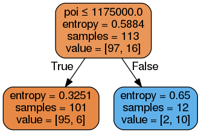

```python
from sklearn.tree import export_graphviz
import pydot
from IPython.display import Image
# dtc = dt.fit(features_e, labels_e)
dot_data = export_graphviz(dt_best_paramsf.named_steps['DT'], out_file=None,
                         feature_names=features_list_e,
                         filled=True, rounded=True,
                         special_characters=True)
graph = pydot.graph_from_dot_data(dot_data)
Image(graph.create_png())
```

### Plot the confusion matrix

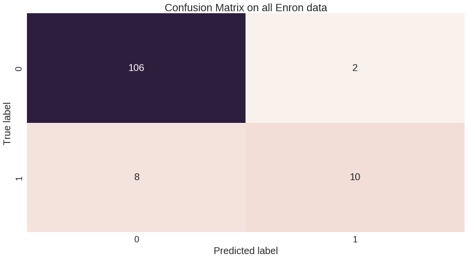

```python
from sklearn.metrics import confusion_matrix

y_pred = gsf.predict(features_e)
y_true = labels_e

cm = confusion_matrix(y_true, y_pred)
cm_df = pd.DataFrame(cm)
plt.figure(figsize = (16,8))
sns.heatmap(cm_df, annot=True, fmt="d", cbar=False, annot_kws={"size": 20})
plt.title("Confusion Matrix on all Enron data")
plt.xlabel("Predicted label")
plt.ylabel("True label")
```

### Classification Report

```python
# Classification report for the final dataset
from sklearn.metrics import classification_report
target_names = ["not_poi", "poi"]
print(classification_report(y_true, y_pred, target_names=target_names))
```

```
             precision    recall  f1-score   support

    not_poi       0.93      0.98      0.95       108
        poi       0.83      0.56      0.67        18

avg / total       0.92      0.92      0.91       126
```

For cross validation, I choose to use Stratifiedshufflesplit iterator. Since this dataset exhibit a large imbalance in the distribution of the target classes, stratified sampling is used to ensure that relative class frequencies is preserved in each train and validation fold.

Using the confusion matrix and the classification report. We are able to see how the final decision tree model performs on the training/testing set as well as the whole dataset. The matrix is a 2x2 which means that we have two classes. Either an employee at Enron is a poi or not a poi.

> - **True Positives (TP):** we correctly predicted that the Enron employee is poi
> - **True Negatives (TN):** we correctly predicted that the Enron employee is not poi
> - **False Positives (FP):** we incorrectly predicted that the Enron employee is poi (a "Type I error")
> - **False Negatives (FN):** we incorrectly predicted that the Enron employee is not poi (a "Type II error")

Overall, tuning the classifier parameters did help us build a more effective model but this is computationally expensive and very time consuming. We cannot assume a certain parameters or using a meta-algorithm will improve the model. In the case of using Adaboost above, we actually see the performance dropped.

For future work, I would like to incorporate email data into the dataset. By implement "a bag of word" to create new features, this could possibly identify communication patterns that will help our model be more precise and yield better predictions. We could also iuncorporate a recursive feature elimination method into the pipeline to see how the classifier perform.

# References

Here are a few major references used for this project.

[Udacity Discussion Forum](https://discussions.udacity.com/t/having-trouble-with-gridsearchcv/186377/6)  
[Sci-kit Learn](http://scikit-learn.org/stable/)  
[Machine learning decision tree](http://christianherta.de/lehre/dataScience/machineLearning/decision-trees.php)  
[Machine learning mastery](http://machinelearningmastery.com/automate-machine-learning-workflows-pipelines-python-scikit-learn/)  
[Select kbest](http://nullege.com/codes/search/sklearn.feature_selection.SelectKBest)  
[Feature scaling](http://sebastianraschka.com/Articles/2014_about_feature_scaling.html#feature-scaling---standardization)  
[Machine learning Mark Ham](https://github.com/justmarkham/scikit-learn-videos/blob/master/09_classification_metrics.ipynb)  
[Sample Enron Project](https://github.com/myaqoob67/Udacity_ML/blob/master/scripts/final_project.ipynb)  
[Seaborn scatterplots](https://chrisalbon.com/python/seaborn_scatterplot.html)  
[Seaborn plots](https://seaborn.pydata.org/)  
[Machine learning advice](https://jmetzen.github.io/2015-01-29/ml_advice.html)